# Lab 6: Regression, Again

P. Johnson, B. Rogers, L. Shaw

Wednesday, March 4, 2015

# Again, the publicspending.txt data.

- EX: Per capita state and local public expenditures ($)
- ECAB: Economic ability index, in which income, retail sales, and the value of output (manufactures, mineral, and agricultural) per capita are equally weighted.
- MET: Percentage of population living in standard metropolitan areas
- GROW: Percent change in population, 1950-1960
- YOUNG: Percent of population aged 5-19 years
- OLD: Percent of population over 65 years of age
- WEST: Western state (1) or not (0)
- STATE: Abbreviation of state

# Get Data

```r
if (!file.exists("publicspending.txt")){
    lab5.url <- "http://pj.freefaculty.org/guides/stat/DataSets/PublicSpending/publicspending.txt"
    download.file(lab5.url, destfile = "publicspending.txt")
}
dat <- read.table("publicspending.txt", header = TRUE)
```

- lets lower-case the variable names

```r
colnames(dat) <- tolower(colnames(dat))
```

# Inspect data, check for typos, etc

```r
library(rockchalk)
summarize(dat)
```

```
## $numerics
##        ecab     ex    grow    met    old   west  young
## 0%    57.40  183.0  -7.400   0.00  5.400  0.000 24.000
## 25%   85.40  253.5   6.975  24.10  7.950  0.000 26.400
## 50%   95.30  285.5  14.050  46.15  9.450  0.500 28.000
## 75%  105.10  324.0  22.675  69.97 10.425  1.000 29.625
## 100% 205.00  454.0  77.800  86.50 11.900  1.000 32.900
## mean  96.75  286.6  18.729  46.17  9.213  0.500 28.115
## sd    22.25   58.8  18.875  26.94  1.639  0.505  2.149
## var  495.19 3456.8 356.256 725.70  2.687  0.255  4.616
## NA's   0.00    0.0   0.000   0.00  0.000  0.000  0.000
## N     48.00   48.0  48.000  48.00 48.000 48.000 48.000
##
## $factors
## NULL
```

# Lets create a factor variable for the state’s location

```r
dat$region <- factor(dat$west, levels = c(0, 1), labels = c("East", "West"))
```

- factor variables are in the core emphasis of the movement behind the S and R languages. It has been adopted by SAS and Stata as well.
- region has 2 values, “East” and “West”.
- In a regression model, R will choose the second label and estimate a variable “regionWest”

# Labels improve output

- tables look nicer. Which would you rather read?

```r
table(dat$west)
```

```
##
##  0  1
## 24 24
```

or

```r
table(dat$region)
```

```
##
## East West
##   24   24
```

- Would you say a state’s classification is better called *region* or *west*?

# How to Choose Variables?

- Wish we had a Substantive Theory
- Wish we had an “oracle” to tell us the right model
- A model with a lot of variables: $ex_i = \beta_0 + \beta_1 ecab_i + \beta_2 met_i + \beta_3 grow +$ $\beta_4 young_i + \beta_5 old_i + \beta_6 regionWest + e_i$
- Some of those $\beta$s might actually be 0. That’s what we assume when we remove a variable.

# R formula

- A formula to estimate all of those in R would be

  ```
  lm(ex ~ ecab + met + grow + young +  old + region, data = dat)
  ```

- That’s the “kitchen sink” model. (Ridicule)

# Fit a multiple regression model

```r
m1 <-lm(ex ~ ecab + met + grow, data = dat)
```

- m1 is an “object”, meaning an entity that
  - holds some data
  - for which we have functions to “extract” and view the data

# Summary is the most frequently used follow-up

- If you are used to SAS or SPSS, the R output from summary will be most similar to the usual “regression table”

```r
summary(m1)
```

```
##
## Call:
## lm(formula = ex ~ ecab + met + grow, data = dat)
##
## Residuals:
##    Min     1Q Median     3Q    Max
## -82.89 -26.49  -1.63  23.89  92.46
##
## Coefficients:
##             Estimate Std. Error t value Pr(>|t|)
## (Intercept)  130.815     28.136    4.65  3.0e-05 ***
## ecab           1.816      0.321    5.65  1.1e-06 ***
## met           -0.709      0.258   -2.75   0.0086 **
## grow           0.686      0.378    1.82   0.0763 .
## ---
## Signif. codes:  0 '***' 0.001 '**' 0.01 '*' 0.05 '.' 0.1 ' ' 1
##
## Residual standard error: 41.9 on 44 degrees of freedom
## Multiple R-squared:  0.525,  Adjusted R-squared:  0.493
## F-statistic: 16.2 on 3 and 44 DF,  p-value: 3.01e-07
```

# Lets stop and think

- Thats just the “vanilla” output, the material that social customs call for (among statistical programmers)
- Take a moment to
  - Write out the theoretical model (with betas!)
  - Write out the equation for calculating predicted values

# The R philosophy: interrogate the fitted model object

- Ever wonder how many functions you could apply to an object of that type?

```r
methods(class = class(m1))
```

```
##  [1] add1.lm*           alias.lm*          anova.lm*
##  [4] case.names.lm*     confint.lm         cooks.distance.lm*
##  [7] deviance.lm*       dfbeta.lm*         dfbetas.lm*
## [10] drop1.lm*          dummy.coef.lm      effects.lm*
## [13] extractAIC.lm*     family.lm*         formula.lm*
## [16] hatvalues.lm*      influence.lm*      kappa.lm
## [19] labels.lm*         logLik.lm*         model.frame.lm*
## [22] model.matrix.lm    nobs.lm*           plot.lm*
## [25] plotSlopes.lm*     predict.lm         print.lm*
## [28] proj.lm*           qqnorm.lm*         qr.lm*
## [31] residuals.lm       rstandard.lm*      rstudent.lm*
## [34] simulate.lm*       standardize.lm*    summary.lm
## [37] variable.names.lm* vcov.lm*
##
##    Non-visible functions are asterisked
```

- In this class, we will eventually discuss about 9 of these (have to leave some work for tomorrow)

# You can dissect the summary output

- Sometimes, it is impossible to get your work done with the standard summary, so you can tear into the model and its summary.
- There are various ways to grab numbers from the guts of m1, the recommended way is to use accessor methods, but sometimes we grab directly.
- See what you might grab like this

```r
names(m1)
```

```
##  [1] "coefficients"  "residuals"     "effects"       "rank"
##  [5] "fitted.values" "assign"        "qr"            "df.residual"
##  [9] "xlevels"       "call"          "terms"         "model"
```

- Perhaps smarter to run attributes (almost same, except shows class)

```r
attributes(m1)
```

```
## $names
##  [1] "coefficients"  "residuals"     "effects"       "rank"
##  [5] "fitted.values" "assign"        "qr"            "df.residual"
##  [9] "xlevels"       "call"          "terms"         "model"
##
## $class
## [1] "lm"
```

# Lets catch a summary object!

```r
m1sum <- summary(m1)
```

- Notice not so many pre-manufactured accessor or follow-up functions

```r
methods(class = class(m1sum))
```

```
## [1] print.summary.lm* vcov.summary.lm*
##
##    Non-visible functions are asterisked
```

- If there is no method to retrieve what you need, a linear model summary object allows access with the $ notation

```r
m1sum$r.squared
```

```
## [1] 0.5254
```

- Can retrieve every named thing in the same way

```r
attributes(m1sum)
```

```
## $names
##  [1] "call"          "terms"         "residuals"     "coefficients"
##  [5] "aliased"       "sigma"         "df"            "r.squared"
##  [9] "adj.r.squared" "fstatistic"    "cov.unscaled"
##
## $class
## [1] "summary.lm"
```

# Extract the coefficient table

```r
coefficients(m1sum)
```

```
##             Estimate Std. Error t value  Pr(>|t|)
## (Intercept) 130.8154    28.1361   4.649 3.041e-05
## ecab          1.8161     0.3214   5.650 1.100e-06
## met          -0.7090     0.2577  -2.751 8.590e-03
## grow          0.6862     0.3780   1.815 7.630e-02
```

- That’s preferred to, but currently, the same as

```r
m1sum$coefficients
```

```
##             Estimate Std. Error t value  Pr(>|t|)
## (Intercept) 130.8154    28.1361   4.649 3.041e-05
## ecab          1.8161     0.3214   5.650 1.100e-06
## met          -0.7090     0.2577  -2.751 8.590e-03
## grow          0.6862     0.3780   1.815 7.630e-02
```

# residuals

- Could grab the residuals from either m1 or m1sum

```r
m1sum$resid
```

```
##       1       2       3       4       5       6       7       8       9
## -20.856 -24.608  35.649  24.365  13.270  -2.061  92.461 -49.488 -11.173
##      10      11      12      13      14      15      16      17      18
##  15.738   2.666 -36.956  16.917 -26.536 -54.490 -19.492  -7.629 -41.376
##      19      20      21      22      23      24      25      26      27
## -48.318 -23.288 -69.807 -52.245 -18.656  -1.203 -12.323   1.697  50.877
##      28      29      30      31      32      33      34      35      36
##   1.117 -44.461  74.090  16.856 -19.795  -8.301  24.520 -39.600  23.734
##      37      38      39      40      41      42      43      44      45
## -35.830  14.171  14.010  32.765 -26.470  85.324  18.416  36.361  50.934
##      46      47      48
##  59.170 -82.889  72.742
```

or

```r
m1$resid
```

```
##       1       2       3       4       5       6       7       8       9
## -20.856 -24.608  35.649  24.365  13.270  -2.061  92.461 -49.488 -11.173
##      10      11      12      13      14      15      16      17      18
##  15.738   2.666 -36.956  16.917 -26.536 -54.490 -19.492  -7.629 -41.376
##      19      20      21      22      23      24      25      26      27
## -48.318 -23.288 -69.807 -52.245 -18.656  -1.203 -12.323   1.697  50.877
##      28      29      30      31      32      33      34      35      36
##   1.117 -44.461  74.090  16.856 -19.795  -8.301  24.520 -39.600  23.734
##      37      38      39      40      41      42      43      44      45
## -35.830  14.171  14.010  32.765 -26.470  85.324  18.416  36.361  50.934
##      46      47      48
##  59.170 -82.889  72.742
```

- There’s a method for that, R team prefers you use it

```r
resid(m1)
```

```
##       1       2       3       4       5       6       7       8       9
## -20.856 -24.608  35.649  24.365  13.270  -2.061  92.461 -49.488 -11.173
##      10      11      12      13      14      15      16      17      18
##  15.738   2.666 -36.956  16.917 -26.536 -54.490 -19.492  -7.629 -41.376
##      19      20      21      22      23      24      25      26      27
## -48.318 -23.288 -69.807 -52.245 -18.656  -1.203 -12.323   1.697  50.877
##      28      29      30      31      32      33      34      35      36
##   1.117 -44.461  74.090  16.856 -19.795  -8.301  24.520 -39.600  23.734
##      37      38      39      40      41      42      43      44      45
## -35.830  14.171  14.010  32.765 -26.470  85.324  18.416  36.361  50.934
##      46      47      48
##  59.170 -82.889  72.742
```

# Formula are very flexible

- R uses the so-called Wilkinson & Rogers (W & R) formula
- Allows some math, we’ll get to that later
- Right now, we need to warn you, “*" does not mean times!

```
lm(ex ~ ecab * met, data = dat)
```

will estimate a model that includes - *ecab*, and - *met*, and also - *ecab:met* which, oddly enough, means multiplication!

# Plotting

# (1) termplot()

- Its supplied with R, so everyboy supposes you know it.
- Displays the predicted Y against Xs.
  - termplot() will generate one plot for each predictor.
- par(mfrow=..) combined plots into a single figure

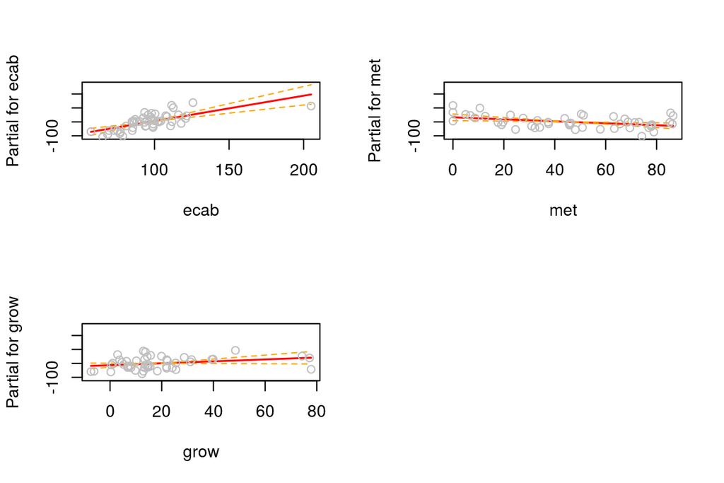

```r
par(mfrow = c(2, 2))
termplot(m1, se = TRUE, partial.resid = TRUE)
par(mfrow = c(1,1)) # change back to the original layout
```

# Choose a particular predictor

- Read ?termplot, see the “terms” argument

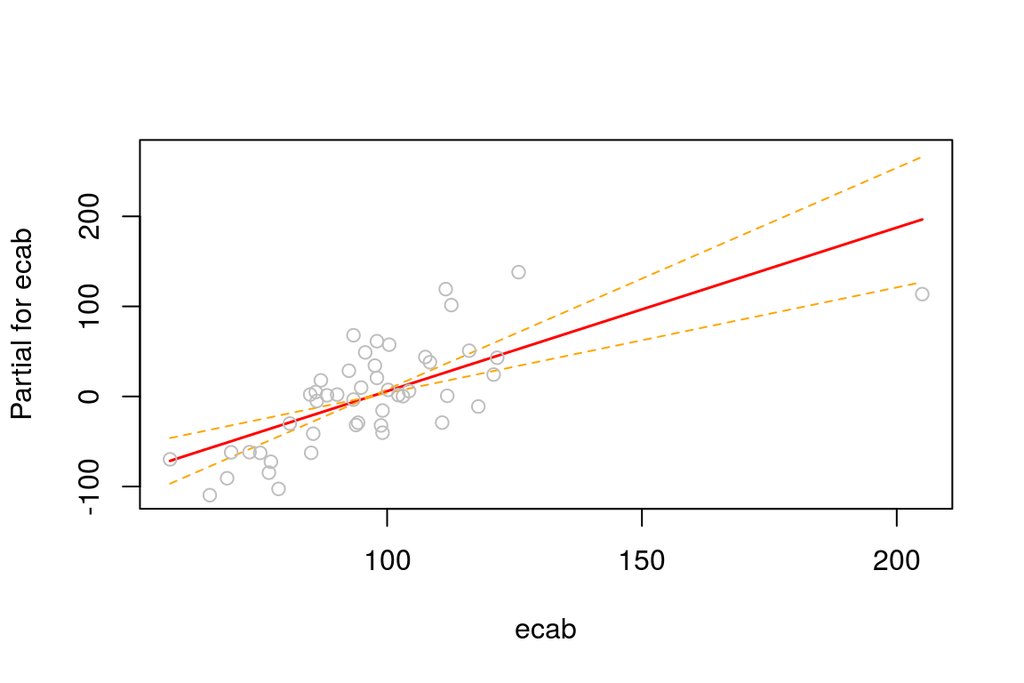

```r
termplot(m1,  se = TRUE, partial.resid = TRUE, terms = "ecab")
```

- Save to file

```r
pdf(file = "m1.ecab.pdf", onefile = FALSE, paper = "special")
termplot(m1,  se = TRUE, partial.resid = TRUE, terms = "ecab")
dev.off()
```

# Predict for “mix and match” of variables

- With no details, it will choose a range of values for each variable, one at a time, and then sets the other variables at central values

```r
predictOMatic(m1, interval = "confidence")
```

```
## $ecab
##    ecab   met  grow   fit   lwr   upr
## 1  57.4 46.17 18.73 215.2 186.9 243.4
## 2  85.4 46.17 18.73 266.0 251.8 280.3
## 3  95.3 46.17 18.73 284.0 271.8 296.2
## 4 105.1 46.17 18.73 301.8 288.5 315.1
## 5 205.0 46.17 18.73 483.2 412.1 554.4
##
## $met
##    ecab   met  grow   fit   lwr   upr
## 1 96.75  0.00 18.73 319.4 292.5 346.3
## 2 96.75 24.10 18.73 302.3 285.6 319.0
## 3 96.75 46.15 18.73 286.7 274.5 298.8
## 4 96.75 69.97 18.73 269.8 252.4 287.1
## 5 96.75 86.50 18.73 258.1 233.8 282.3
##
## $grow
##    ecab   met   grow   fit   lwr   upr
## 1 96.75 46.17 -7.400 268.7 245.4 292.1
## 2 96.75 46.17  6.975 278.6 263.5 293.7
## 3 96.75 46.17 14.050 283.4 270.7 296.1
## 4 96.75 46.17 22.675 289.4 276.8 301.9
## 5 96.75 46.17 77.800 327.2 280.6 373.8
```

- That’s the “default”, same as running

```r
predictOMatic(m1, predVals = "margins", interval = "confidence")
```

- The “auto” argument causes a complete mix-and-match

```r
predictOMatic(m1, predVals = "auto", intervals = "confidence")
```

```
## [[1]]
##      ecab   met   grow   fit
## 1    57.4  0.00 -7.400 230.0
## 2    85.4  0.00 -7.400 280.8
## 3    95.3  0.00 -7.400 298.8
## 4   105.1  0.00 -7.400 316.6
## 5   205.0  0.00 -7.400 498.0
## 6    57.4 24.10 -7.400 212.9
## 7    85.4 24.10 -7.400 263.7
## 8    95.3 24.10 -7.400 281.7
## 9   105.1 24.10 -7.400 299.5
## 10  205.0 24.10 -7.400 480.9
## 11   57.4 46.15 -7.400 197.3
## 12   85.4 46.15 -7.400 248.1
## 13   95.3 46.15 -7.400 266.1
```

[output cut: 112 more lines]

- The predVals “predictor values” argument is flexible

```r
# predictOMatic(m1, predVals = list(ecab = "std.dev", met = "quantile"), intervals = "confidence")
```

- In case predictOMatic fails you, drop back to inspect the newdata function.

```r
new1 <- newdata(m1, predVals="auto", divider="quantile") # quantile is default
new1
```

```
##     ecab   met   grow
## 1   85.4 24.10  6.975
## 2   95.3 24.10  6.975
## 3  105.1 24.10  6.975
## 4   85.4 46.15  6.975
## 5   95.3 46.15  6.975
## 6  105.1 46.15  6.975
## 7   85.4 69.97  6.975
## 8   95.3 69.97  6.975
## 9  105.1 69.97  6.975
## 10  85.4 24.10 14.050
## 11  95.3 24.10 14.050
## 12 105.1 24.10 14.050
## 13  85.4 46.15 14.050
## 14  95.3 46.15 14.050
## 15 105.1 46.15 14.050
## 16  85.4 69.97 14.050
## 17  95.3 69.97 14.050
## 18 105.1 69.97 14.050
## 19  85.4 24.10 22.675
## 20  95.3 24.10 22.675
## 21 105.1 24.10 22.675
## 22  85.4 46.15 22.675
## 23  95.3 46.15 22.675
## 24 105.1 46.15 22.675
## 25  85.4 69.97 22.675
## 26  95.3 69.97 22.675
## 27 105.1 69.97 22.675
```

```r
predict(m1, newdata = new1)
```

```
##     1     2     3     4     5     6     7     8     9    10    11    12
## 273.6 291.6 309.4 258.0 276.0 293.7 241.1 259.1 276.9 278.5 296.4 314.2
##    13    14    15    16    17    18    19    20    21    22    23    24
## 262.8 280.8 298.6 245.9 263.9 281.7 284.4 302.4 320.2 268.7 286.7 304.5
##    25    26    27
## 251.9 269.8 287.6
```

- You can use *new1* as a *newdata* object in any of the R predict methods.

# (2) rockchalk::plotPlane()

- creates a 3D plot of the predicted Y against a plane formed by two Xs.

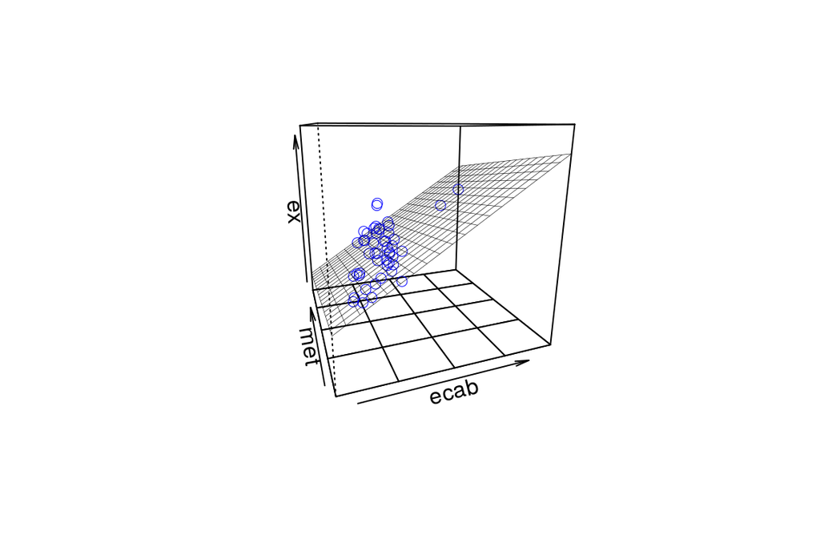

```r
plotPlane(m1, plotx1 = "ecab", plotx2 = "met")
```

- This function has quite a few arguments that can be used to beautify the output

# The fancy t-test

- The difficult thing for most students is imagining a situation in which they would actually want to know if two coefficients are actually equal.
- consider the garbage can model

```r
m2 <- lm(ex ~ ecab + met + grow + old + young, data = dat)
```

- We wonder whether the coefficient of “grow” (b3) is significantly different from the coefficient of “young” (b5).
- To do that, we need to calculate this t statistic

$\hat{t} = \frac{\hat{\beta_3}-\hat{\beta_5}}{std.err.(\hat{\beta_3}-\hat{\beta_5})}$

- To calculate the denominator, we need to get the values of the variances and covariance of $\beta_3$ and $\beta_5$
- Its easier to believe that estimates for all those values *could* be retrieved than to actually do it.
- Class controversy in past 3 years is whether PJ should write a function to “just do it”. So far, the majority view has been
  - This is not very difficult, people can do it.

m2sum <- summary(m2)

m2sum$coef # returns a matrix of the t table.

m2sum$coef[ ,1] # returns the first column of the t table, which contains the regression coefficients. - Note that b3 is the fourth element, and b5 is the sixth element in the vector.

- Give a name to the result of vcov(m2). The result is a matrix. vc <- vcov(m2)
- Again, we use [,] to specify the elements in the matrix.
- For example, vc[4,6] is the element in the forth row and the six column.

fancyt <- (m2sum$coef[4,1] - m2sum$coef[6,1])/sqrt( vc[4,4]+vc[6,6]-2* vc[4,6]) fancyt